# Machine Learning

Daniel Stein (dcstein2)

30/01/2022

# Question 1 (concept)[20p]

For each of parts (a) through (d), indicate whether we would generally expect the performance of a flexible statistical learning method to be better or worse than an inflexible method. Justify your answer.

1. The sample size $n$ is extremely large, and the number of predictors $p$ is small.
2. The number of predictors $p$ is extremely large, and the number of observations $n$ is small.
3. The relationship between the predictors and response is highly non-linear.
4. The variance of the error terms, $Var(\epsilon)$, is extremely high.

# Answer 1

1. When the sample size is large and the number of independent variables are small, I expect a flexible statistical learning method to be better because $\hat{f}(x_{0})$ would fit the data better due to a larger sample size.
2. When $p>n$, a flexible learning method is worse because of overfitting the data. This will result in a high test $MSE$.
3. The flexible learning method would be better if the relationship between the predictors and the response is highly non-linear. Flexible learning methods eliminate bias in the estimates for non-linear relationships whereas inflexible methods will have extremely high bias and high variance.
4. A high variance in the irreducible error term will make a flexible learning method worse because flexible learning methods will try and predict the random noise element causing high variance in $\hat{f}(x_{0})$.

# Question 2 (concept)[10p]

Explain whether each scenario is a classification or regression problem, and indicate whether we are most interested in inference or prediction. Finally, provide $n$ and $p$.

1. We collect a set of data on the top 500 firms in the US. For each firm we record profit, number of employees, industry and the CEO salary. We are interested in understanding which factors affect CEO salary.
2. We are considering launching a new product and wish to know whether it will be a *success* or a *failure*. We collect data on 20 similar products that were previously launched. For each product we have recorded whether it was a success or failure, price charged for the product, marketing budget, competition price, and ten other variables.
3. We are interested in predicting the % change in the USD/Euro exchange rate in relation to the weekly changes in the world stock markets. Hence we collect weekly data for all of 2012. For each week we record the % change in the USD/Euro, the % change in the US market, the % change in the British market, and the % change in the German market.

# Answer 2

1. This is a regression problem because we are trying to inference changes in CEO salary, hence the response variable is quantitative. $N=500, P = 3$
2. This is a classification problem because the response variable is qualitative. $N=20, P=13$. Here we are interested in prediction.
3. Regression problem and we are interested in prediction. $N= 52, P = 3$.

# Question 3 (concept)[20p]

We now revisit the bias-variance decomposition.

1. Provide a sketch of typical (squared) bias, variance, training mean squared error, test mean squared error, and Bayes (or irreducible) error rate curves, on a single plot, as we go from less flexible statistical learning methods towards more flexible approaches. The $x$-axis should represent the amount of flexibility in the method, and the $y$-axis should represent the values for each curve. There should be five curves. Make sure to label each one.
2. Explain why each of the five curves has the shape displayed in part (a)

# Answer 3

1. Here, either you’re going to sketch the graph, take a picture and attach it (make sure you are using the right file format, for example it could be .jpg or .png), this way:

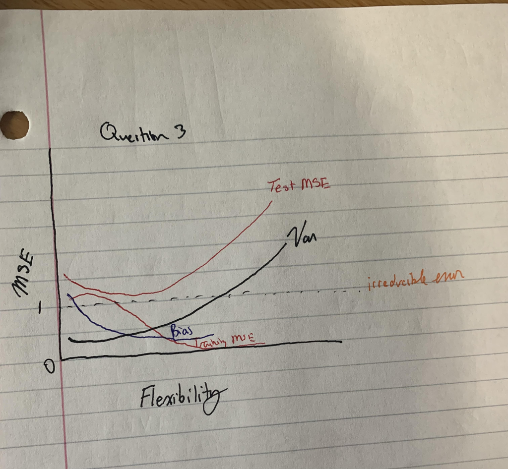

Question 3 Graph

2. *Typical squared bias* always decreases as flexibility increases because flexible learning methods can accurately estimate a real-life problem better than inflexible methods, especially when the true relationship is non-linear. *Training MSE** always declines as flexiblity grows because bias continually declines which produces a better $\hat{f}(x_{1})$ to fit the training data. *Variance* always increases as flexibility grwos. For example, if the training or test data have a high variance, htne small changes in the data result in large changes in $\hat{f}$. *Test MSE* is U-shaped due to the relative rate of change in bias and variance. As flexibility increases, bias tends to fall faster than variance causing a decline in test MSE, however, beyone a certain point increasing flexibility does little to change the bias so the variance increases significantly, causing test MSE to increase.

# Question 4 (concept)[20p]

The table below provides a training data set containing six observations, three predictors, and one qualitative response variable

Obs.

$X_1$

$X_2$

$X_3$

$Y$

0

3

0

Red

2

0

0

Red

0

1

3

Red

0

1

2

Green

-1

0

1

Green

1

1

1

Red

Suppose we wish to use this data set to make a prediction for $Y$ when $X_1 = X_2 = X_3 = 0$ using K-nearest neighbors.

1. Compute the Euclidean distance between each observation and the test point, $X_1 = X_2 = X_3 = 0$.

(Note: the Euclidean distance of two vectors $a = (a_1,a_2,a_3)$ and $b = (b_1,b_2,b_3)$ is given by $d(a,b) = \sqrt{(a_1-b_1)^2 + (a_2-b_2)^2 + (a_3-b_3)^2}$. The same idea extends to vectors with $n$ coordinates.)

2. What is our prediction with K = 1? Why?
3. What is our prediction with K = 3? Why?
4. If the Bayes decision boundary in this problem is highly non-linear, then would we expect the best value for K to be large or small? Why?

# Answer 4

1. Here it would be recommended to create a table (or choose any way want to provide your answer):

Obs.

$X_1$

$X_2$

$X_3$

$d\big(obs, (0,0,0) \big)$

0

3

0

```
         3
```

2

0

0

```
         2
```

0

1

3

```
         3.162
```

0

1

2

```
         2.236
```

-1

0

1

```
         1.414
```

1

1

1

```
         1.732
```

$\Pr(Y=green|X=x_{0})$ = $\frac{1}{1}\sum_{i= N_{0}}^{i} I(Y_{i}=Green)$ equals 1.

$\Pr(Y=Red|X=x_{0})$ = $\frac{1}{1}\sum_{i= N_{0}}^{i} I(Y_{i}=Red)$ equals 0.

The shortest distance from the vector $ [0,0,0]$ is observation 5, which was green.

3. $\Pr(Y=green|X=x_{0})$ = $\frac{1}{3}\sum_{i= N_{0}}^{i} I(Y_{i}=Green)$ equals $\frac{1}{3}$.

$\Pr(Y=Red|X=x_{0})$ = $\frac{1}{3}\sum_{i= N_{0}}^{i} I(Y_{i}=Red)$ equals $\frac{2}{3}$

Since $\frac{2}{3} > \frac{1}{3}$ our prediction with $K = 3$ is *red.*

4. If the Bayes decision boundary is highly non-linear, then we would expect the best value of K to be small since smaller values of K represent more flexible approaches for a classifcation setting.